# California Food Affordability

### R analysis by Dan Spector

#### This is a dataset from California Health and Human Services about food affordability in Californian female-headed households with children.

```r
filtered_data <- filter(food_data, geoname != "California" & race_eth_name != "Total")
```

#### Standard Error

I will illustrate the standard error by drawing a random sample of food cost per year.

Here I calculate several summary statistics The histogram shows he dataset as a whole is positively skewed:

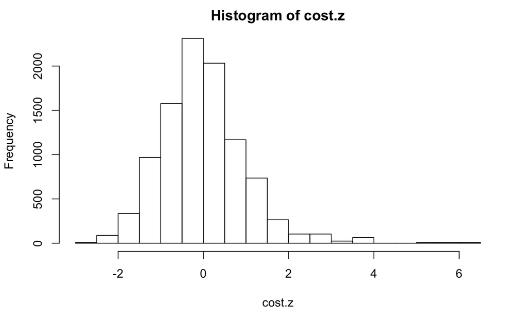

```r
cost <- (filtered_data$cost_yr)
cost.mean <- mean(cost, na.rm = TRUE)
cost.sd <- sd(cost, na.rm = TRUE)
cost.z <- (cost - cost.mean) / cost.sd
hist(cost.z)
```

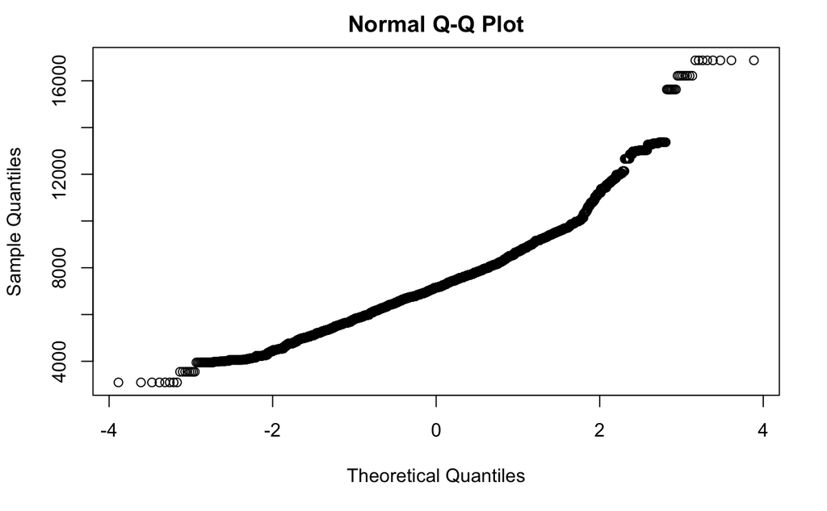

```r
qqnorm(cost)
```

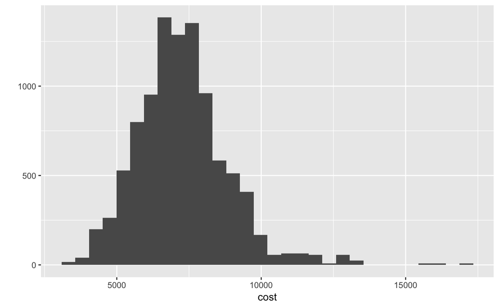

```r
qplot(cost)
```

These graphs also show the data is not normally distributed.

Now I want to create a random sample of 100 cost per years, and see the distribution of the sample.

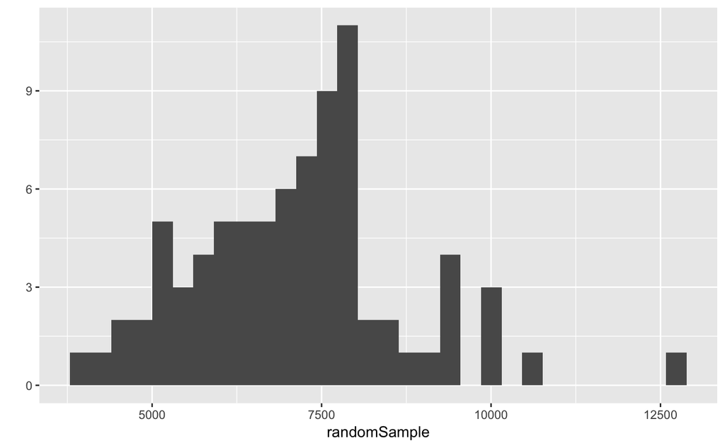

```r
randomSample <- sample(cost, 100)
qplot(randomSample)
```

The sample also appears positively skewed. Now, I want to compare the population mean with the sample mean, and calculate the standard error.

```r
means <- c(population = cost.mean, sample = mean(randomSample, na.rm = TRUE))
standardError <- sd(randomSample, na.rm = TRUE) / sqrt(length(randomSample))
standardError
```

```
[1] 155.5461
```

I will calculate a confidence interval of 95%. I will add and subtract the ci from the sample mean, which will give me the confidence interval.

```r
ci <- qnorm(0.975) * standardError
ci
```

```
[1] 304.8648
```

```r
# calculate 95% conf. interval
m <- means[2]
conf.int <- c(low=m-ci,high= m+ci)
conf.int
```

```
 low.sample high.sample
   6837.256    7446.985
```

There is 95% confidence that the actual population mean is between those two values. Indeed, the actual population mean is 7268.952, which is between these two values.

#### Unpaired T test

Now I will take two samples of 50 observations each and see if the difference in their means is significant. I’m pretty sure I should use an unpaired T test, since the groups aren’t before/after and are independent.

```r
sample1 <- sample(cost, 50)
sample2 <- sample(cost, 50 )
t.test(sample1, sample2, paired= FALSE)
```

```
    Welch Two Sample t-test

data:  sample1 and sample2
t = -0.96594, df = 71.978, p-value = 0.3373
alternative hypothesis: true difference in means is not equal to 0
95 percent confidence interval:
 -1008.3124   350.0957
sample estimates:
mean of x mean of y
 6901.053  7230.162
```

T is small, p-value is over .05, therefore the difference in means is not significant.

#### Effect size

```r
abs(mean(sample1, na.rm = TRUE) - mean(sample2, na.rm = TRUE))
```

```
[1] 329.1084
```

```r
cohen <- (mean(sample2, na.rm = TRUE)-mean(sample1, na.rm = TRUE))/
  sqrt(
    (sd(sample1, na.rm = TRUE)^2+sd(sample2, na.rm = TRUE)^2) / 2
  )
cohen
```

```
[1] 0.2244392
```

Effect size is very small, therefore the result is not statistically significant.